# Logistic Regression

## Where we left off

- **Day 11:** classification predicts a category.
  - Will this customer default on a new loan? If likely, the bank denies it.
  - Linear regression on a 0/1 outcome gave negative “probabilities.”
  - We scored classifiers with the confusion matrix, recall, precision, and F1.
  - Our best classifier, balance > $2,000, was **picked by eye**. Nothing was optimized.
- **Today: logistic regression.**
  - A curve that always stays between 0 and 1
  - Coefficients **chosen by optimizing**, like least squares on Day 10
  - Reading its coefficients, with one or several predictors
  - Turning its probabilities into Yes/No predictions

## Bending the line

> **Day 11’s line went below 0. What shape should the probability of default have?**

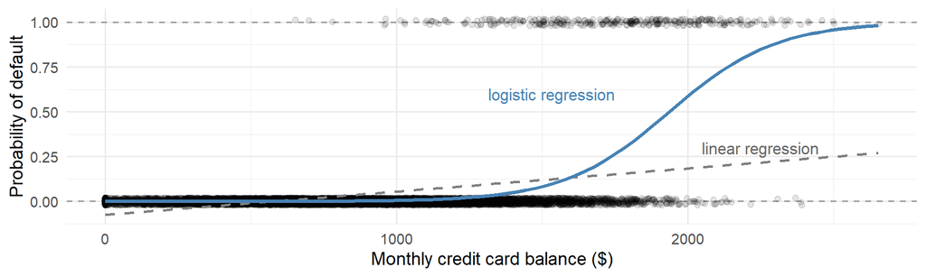

- Flat near 0 for low balances, rising steeply around $2,000, flattening near 1.
- **Logistic regression** fits this S-shaped curve.

## The logistic function

Two steps take a customer’s balance \(X\) to a probability:

1. **Score:** \(z = \beta_0 + \beta_1 X\). A straight line, so any number. Not a probability.
2. **Probability:** \(p(X) = e^{z} / (1 + e^{z})\). The chance of default at balance \(X\), always between 0 and 1.

|  | z = -4 | z = -2 | z = 0 | z = 2 | z = 4 |
| --- | --- | --- | --- | --- | --- |
| **p(X)** | 0.02 | 0.12 | 0.50 | 0.88 | 0.98 |

- \(z = 0\) gives a coin flip. Big \(z\): near 1. Very negative \(z\): near 0.
- \(\beta_1 > 0\): the curve rises with \(X\). \(\beta_1 < 0\): it falls.

## Fitting it in R

`glm()` (“generalized linear model”) with `family = binomial`:

```r
fit_bal <- glm(default ~ balance, data = Default, family = binomial)
coef(fit_bal)
##   (Intercept)       balance
## -10.651330614   0.005498917
```

- The criterion is **maximum likelihood**: choose the coefficients that make the defaults we actually saw as likely as possible. (Least squares plays this role in linear regression.)
- `summary(fit_bal)` reads like Day 10’s: estimates, standard errors, and p-values. The **z value** plays the role of the t value.

## Making a prediction

> **What’s the chance a customer with a $1,000 balance defaults? A $2,000 balance?**

Plug into \(z\), then into \(p\):

\[z = -10.65 + 0.0055 \times 1000 = -5.15 \qquad p = \frac{e^{-5.15}}{1 + e^{-5.15}} = 0.0058\]

R does both steps with `type = "response"`:

```r
predict(fit_bal, data.frame(balance = c(1000, 2000)), type = "response")
##           1           2
## 0.005752145 0.585769370
```

0.6% at $1,000; 59% at $2,000.

## 1. Reading the coefficients

## Between \(z\) and \(p\): the odds

> **The score \(z\) can be any number. How does it become a probability?**
- The **odds** compare the chance it happens to the chance it doesn’t: \(\text{odds} = p / (1 - p)\).
  - \(p = 0.8\) is odds of \(0.8 / 0.2 = 4\), “4 to 1.”
  - Back again: \(p = 4 / (1 + 4) = 0.8\).
- The logistic function passes through the odds on its way to \(p\):

\[z \quad\xrightarrow{\ \ e^{z}\ \ }\quad \text{odds} \quad\xrightarrow{\ \ \text{odds} / (1 + \text{odds})\ \ }\quad p\]

- So \(e^{z}\) is the odds, and \(z\) is the log of the odds: the **log-odds**.
- \(z = 0\): odds \(e^0 = 1\), so \(p = 0.5\). The coin flip from before.

## One customer, $100 at a time

> **What does an extra $100 of balance do to \(z\), the odds, and \(p\)?**

| Balance | Score z | Odds | Probability p | Rise in p |
| --- | --- | --- | --- | --- |
| $1,500 | -2.40 | 0.090 | 8.3% |  |
| $1,600 | -1.85 | 0.157 | 13.6% | 5.3 points |
| $1,700 | -1.30 | 0.272 | 21.4% | 7.8 points |
| $1,800 | -0.75 | 0.471 | 32.0% | 10.6 points |
| $1,900 | -0.20 | 0.816 | 44.9% | 12.9 points |
| $2,000 | 0.35 | 1.414 | 58.6% | 13.6 points |
| $2,100 | 0.90 | 2.451 | 71.0% | 12.4 points |

- **z:** up 0.55 every step (\(100 \times \hat\beta_1\)). A straight line.
- **Odds:** multiplied by \(e^{0.55} = 1.73\) every step, wherever you start.
- **p:** rises by a different amount each step. The S-curve is steepest in the middle.

## \(\beta_1\) in linear vs logistic regression

> **On Day 10, \(\beta_1\) was “the change in \(Y\) when \(X\) rises by 1.” What is it now?**

|  | Linear regression (Day 10) | Logistic regression |
| --- | --- | --- |
| **The straight line predicts** | Y itself | The score z (the log-odds) |
| **X up by 1** | Y changes by β₁ | z changes by β₁, so the odds are **multiplied** by e<sup>β₁</sup> |
| **Effect on the outcome** | The same at every X | The change in p **depends on where you start** |
| **Sign of β₁** | The direction | The direction |

- So the logistic \(\beta_1\) is **not** “the change in \(p\) per unit of \(X\).”
- Balance: \(\hat\beta_1 > 0\), so higher balances mean a higher chance of default.

## 2. More than one predictor

## Multiple logistic regression

Same idea, more terms in \(z\):

\[z = \beta_0 + \beta_1 X_1 + \dots + \beta_p X_p \qquad p = \frac{e^{z}}{1 + e^{z}}\]

| Term | Estimate | p-value |
| --- | --- | --- |
| Intercept | -10.87 | < 0.001 |
| balance | 0.00574 | < 0.001 |
| income | 0.000003 | 0.71 |
| student = Yes | -0.65 | 0.006 |

- Each \(\beta_j\) is read **holding the other predictors fixed**, as on Day 10.
- Balance matters; income doesn’t add anything once balance is known.

## The student puzzle

> **Are students more or less likely to default?**

| Model | Student coefficient | Reading |
| --- | --- | --- |
| `default ~ student` | **+0.40** | Students default more: 4.3% vs 2.9% |
| `default ~ balance + income + student` | **-0.65** | At the same balance and income, students default **less**: 5.8% vs 10.5%, with a $1,500 balance and 40k income |

Both are right. They answer different questions.

## Why the sign flips

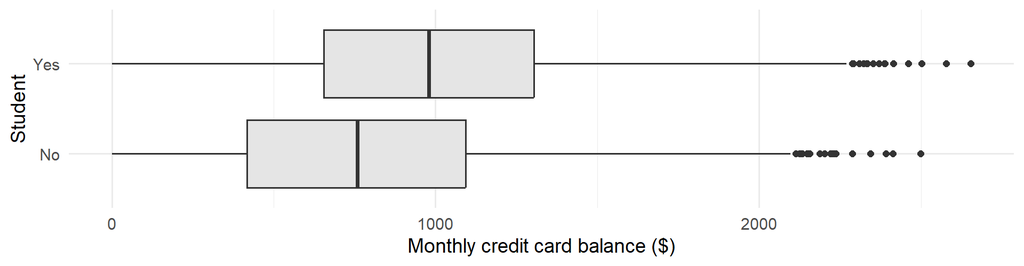

- Students carry higher balances (average $988 vs $772), and high balances drive default.
- Alone, `student` absorbs the balance effect: Day 10’s **omitted variable bias**.
- **Which one to use?** A lender who knows nothing else: a student is riskier. A lender comparing two customers **with the same balance**: the student is safer.

## 3. From probabilities to classes

## Classify with a cutoff

> **Does logistic regression beat Day 11’s balance rule?**

Fit `default ~ balance + student`. The bank **denies a new loan** (predicts **Yes**) when \(p > 0.5\).

| Classifier | Denied | Error rate | Recall | Precision | F1 |
| --- | --- | --- | --- | --- | --- |
| Always No | 0 | 3.3% | 0% | — | 0.00 |
| Day 11 rule: balance > $2,000 | 106 | 2.8% | 24% | 76% | 0.37 |
| Logistic, p > 0.5 | 144 | 2.7% | 32% | 73% | 0.44 |

- Logistic catches more defaulters (32% vs 24%) at similar precision.
- But it still misses 68% of defaulters.
- The model fits the **probabilities**. The 0.5 cutoff is **our choice**, and we can move it.

## Choosing the cutoff

> **Two ways to get a loan wrong. Which way should the cutoff move?**
- **False negative:** lend to someone who defaults. Lose the loan. **Worse.**
- **False positive:** turn away someone who’d repay. Lose some interest.

| Classifier | Denied | Error rate | Recall | Precision | F1 |
| --- | --- | --- | --- | --- | --- |
| Logistic, p > 0.5 | 144 | 2.7% | 32% | 73% | 0.44 |
| Logistic, p > 0.2 | 479 | 4.1% | 61% | 42% | 0.50 |

- **Down.** Fewer false negatives, more false positives.
- The error rate rises, but it treats both mistakes as equally bad.
- Easy to explain: “deny anyone with at least a 20% chance of default.”

## Summary

**Logistic regression** models the probability of a class: \(p = \dfrac{e^{z}}{1 + e^{z}}\) with \(z = \beta_0 + \beta_1 X_1 + \dots + \beta_p X_p\).

- \(p\) always stays between 0 and 1. Fit with `glm(..., family = binomial)`.
- Predict with `predict(..., type = "response")`, or plug in by hand.
- The **sign** of \(\beta_j\) gives the direction. The change in \(p\) depends on where you start; the odds change by a constant factor \(e^{\beta_j}\).
- With several predictors, read each holding the others fixed. Leaving one out can **flip a sign** (the student puzzle).
- Turn \(p\) into Yes/No with a cutoff, chosen by what each mistake costs.

**Next time:** K-nearest neighbors, a classifier with no equation at all.

## For rest of class

- Work on the `day12_activity`
  - you’ll predict whether a college is private from its tuition and size, and solve a puzzle about graduation rates
- Ask me questions if you run into issues